# Презентация лабораторной работы

Лабораторная работа №1

Швецов Михаил Романович

1132236100@rudn.ru

Российский университет дружбы народов

2026-09-02

# Информация

## Докладчик

- **Швецов Михаил Романович**
- студент кафедры теории вероятностей и кибербезопасности
- Российский университет дружбы народов им. П. Лумумбы
- 1132236100@rudn.ru
- https://DarkkLord.github.io/ru/

[figure not shown]

# Выполнение лабораторной работы

Ранее мы установили все необходимые пакеты и сервисы для лабораторной работы.

Устанвока git flow (рис. 1).

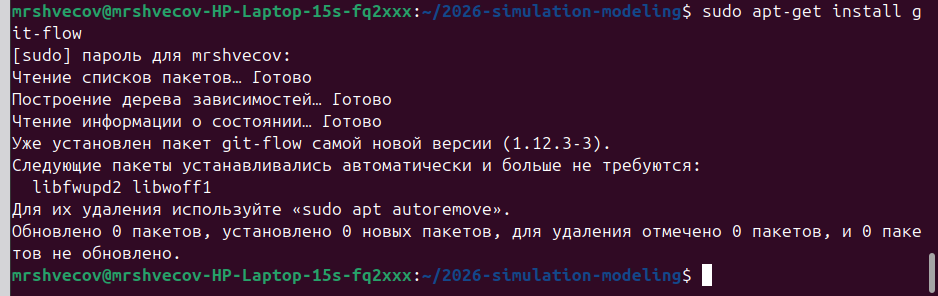

Рисунок 1: Устанвока git flow

Далее мы мотрим доступные цели make (рис. 2).

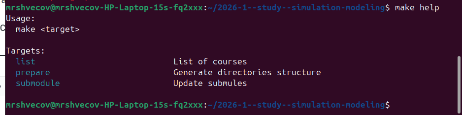

Рисунок 2: Посмотреть доступные цели make:

Далее мы мотрим доступные курсы (рис. 3).

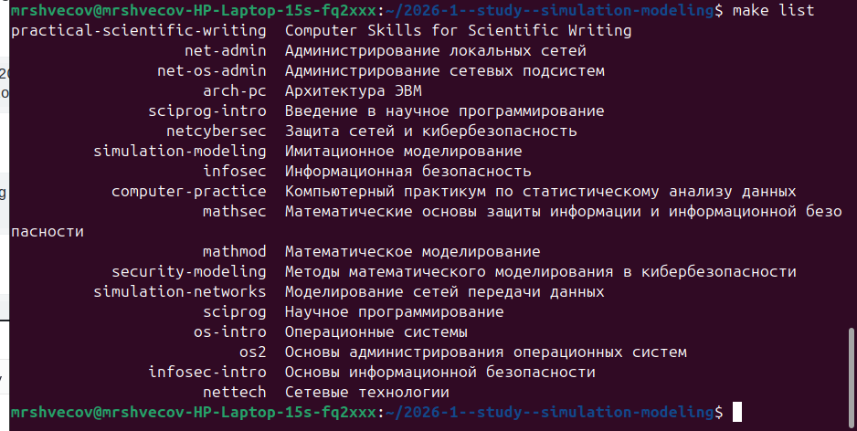

Рисунок 3: Посмотреть доступные курсы в make:

Далее мы переходим в курс и инициализируем курс, отправляем файлы на сервер (рис. 4).

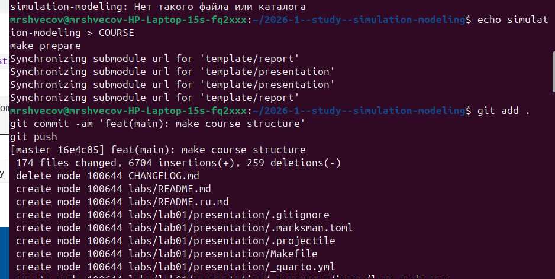

Рисунок 4: Инициализация курса:

Далее мы инициализируем git flow проверяем, что мы на ветке develop и загружаем весь репозиторий в хранилище (рис. 5).

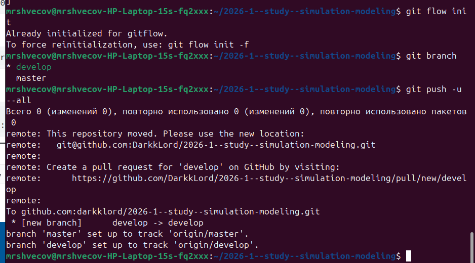

Рисунок 5: Отправка файлов на сервер + инициализация git flow:

Создадим релиз с версией 1.0.0. Создадим журнал изменений. Добавим журнал изменений в индекс. Зальём релизную ветку в основную ветку. Отправим данные на github (рис. 6).

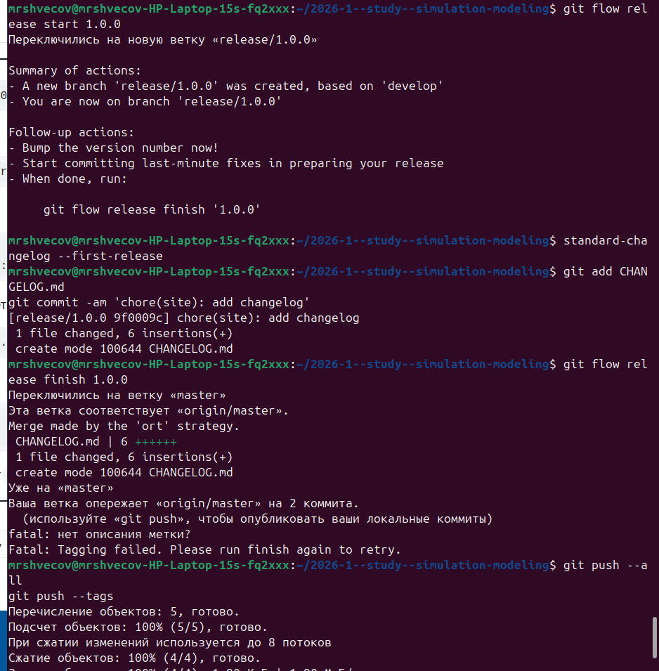

Рисунок 6: Создание релиза, журнала изменений, релиз в основную ветку и отправка на github:

Скопируем CHANGELOG.md в каталог release (рис. 7).

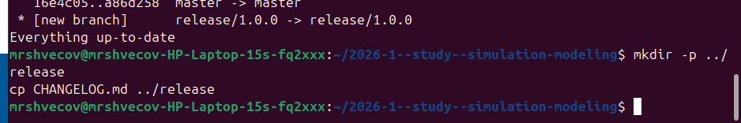

Рисунок 7: CHANGELOG.md в каталог release:

Создадим релиз (рис. 8).

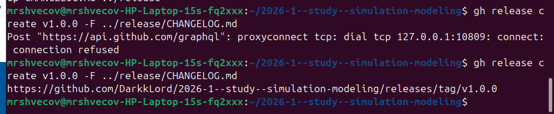

Рисунок 8: Релиз:

Перейдём в каталог лабораторной, откроем julia и выполним код на рисунке (рис. 9).

[figure not shown]

Рисунок 9: Переход в каталог лабораторной и выполнение кода:

Переходим в созданый каталог (рис. 10).

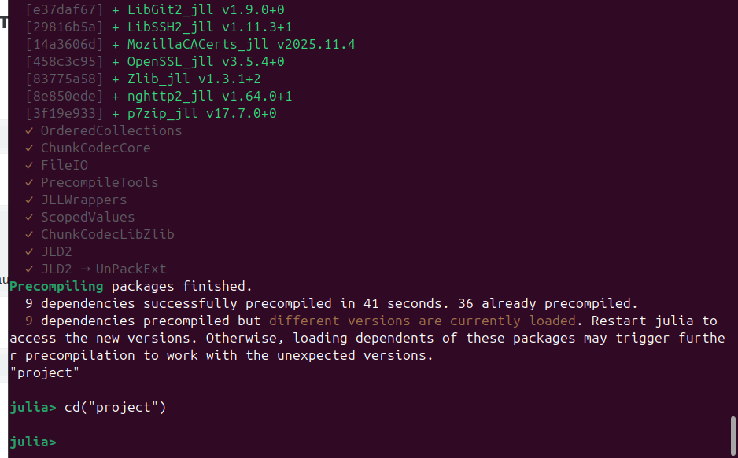

Рисунок 10: Прееход в каталог:

Добавление необходимых пакетов (рис. 11).

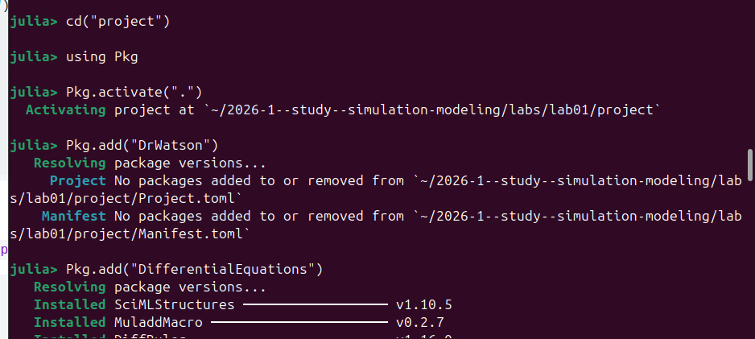

Рисунок 11: Добавление пакетов:

Проверка установленых пакетов (рис. 12).

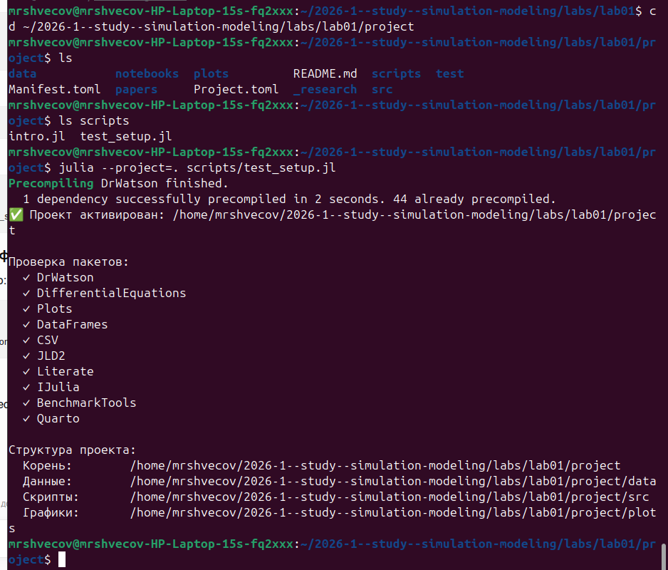

Рисунок 12: Проверка:

Реализация модели экспоненциального роста (рис. 13).

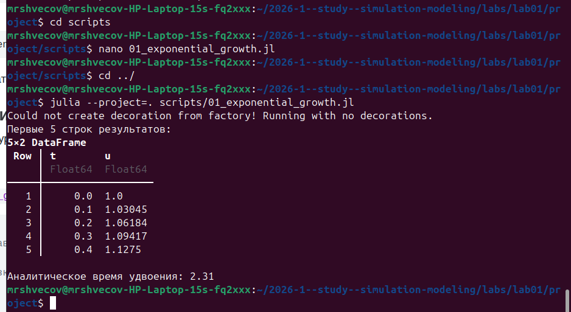

Рисунок 13: Реализация модели:

Просмотр получившегося графика в каталоге /plots (рис. 14).

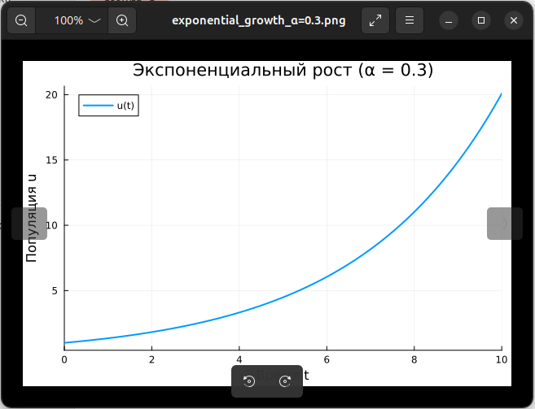

Рисунок 14: Просмотр графика:

Изменяем файл scripts/01_exponential_growth.lj и запускем его (рис. 15).

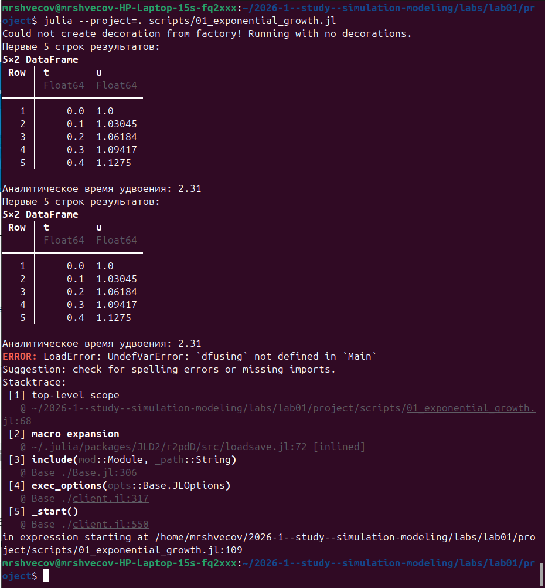

Рисунок 15: Замена и просмотр:

Создадим скрипт для генерации производных форматов (scripts/tangle.jl) (рис. 16).

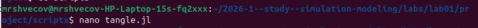

Рисунок 16: Создание файла:

[figure not shown]

Рисунок 17: Выполнение программы:

Создадим производные форматы (scripts/tangle.jl) (рис. 18).

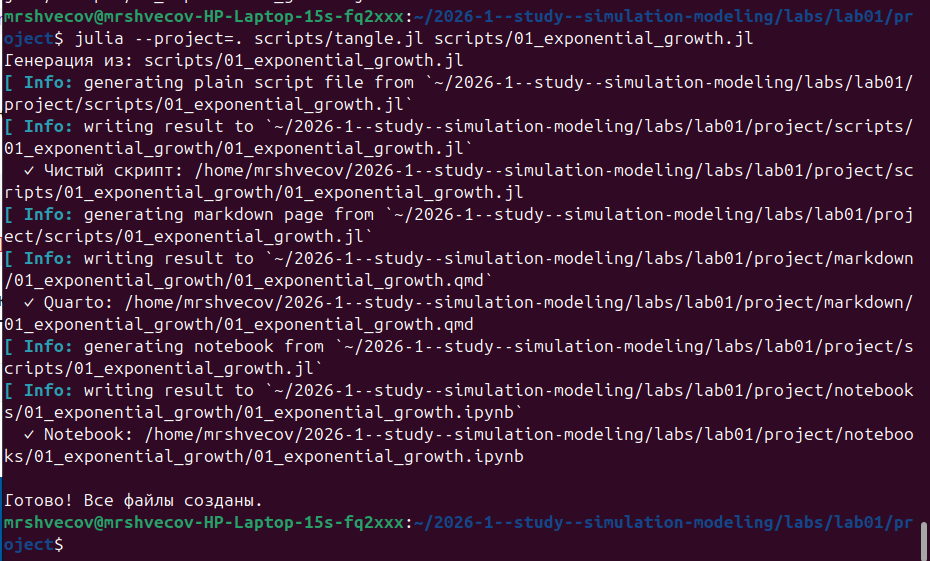

Рисунок 18: Выполнение:

Выполняем Jupyter-ноутбук notebooks/01_exponential_growth/01_exponential_growth.ipynb (рис. 19).

[figure not shown]

Рисунок 19: Результат: получаем файл

В каталоге отчёта в файл _quarto.yml включаем поддержку кода julia. (рис. 20).

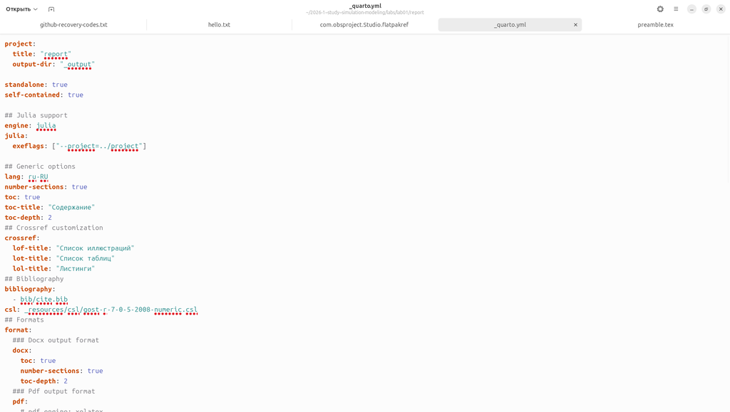

Рисунок 20: Результат:

Перенесём программу в файл scripts/02_exponential_growth.lj и выполним программу (рис. 22).

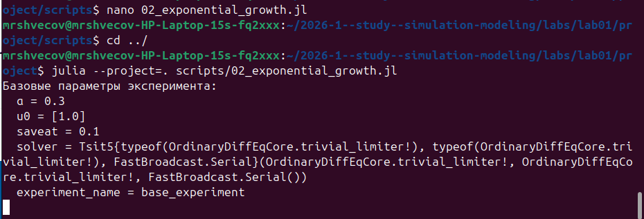

Рисунок 22: Результат:

# Выводы